# A Tutorial of Sample-Pseudotime Aanalysis on COVID scRNA-seq Data

Runzhe Li

Johns Hopkins University

rli51@jhmi.edu

2022-04-06

#### Abstract

# 1 Load packages

```r
library(tidyverse)
library(TreeCorTreat)
library(ggpubr)
library(RColorBrewer)
library(ggrepel)
```

# 2 Read R code

```r
source("./source/demo/util.R")
source("./source/demo/core.R")
source("./source/demo/core_clean.R")
```

# 3 Load data

The input for our pipeline is listed below:

- `leaves_info`: The hierarchical tree structure to reveal the cell type lineage relationship.
- `cell_meta`: The cell meta data frame, which includes the following column names: `celltype`, `barcode`, `sample`
- `sample_meta`: The sample meta data frame, which includes the following column names: `sample`,`study`, `severity`, `batch` and some other clinical variables of interest.
- `raw_count`: The raw gene expression matrix, where each row is a gene and each column is a cell.

```r
leaves_info = readRDS("./data/demo/leaves_info.rds")
cell_meta = readRDS("./data/demo/cell_meta.rds")
sample_meta = readRDS("./data/demo/sample_meta.rds")
raw_count = readRDS("./data/demo/raw_count.rds")

head(leaves_info)
```

```
##   label children     x y id  leaf
## 1   All     T_c1 17.75 2  1 FALSE
## 2   All     T_c2 17.75 2  1 FALSE
## 3   All     T_c3 17.75 2  1 FALSE
## 4   All     T_c4 17.75 2  1 FALSE
## 5   All     T_c5 17.75 2  1 FALSE
## 6   All     T_c6 17.75 2  1 FALSE
```

```r
head(cell_meta)
```

```
##   celltype           barcode      sample old large
## 1     T_c4 CoV-92.1-Su:57254 CoV-92.1-Su  c4     T
## 2    B_c24 CoV-92.1-Su:57255 CoV-92.1-Su c24     B
## 3    B_c24 CoV-92.1-Su:57256 CoV-92.1-Su c24     B
## 4 Mono_c14 CoV-92.1-Su:57257 CoV-92.1-Su c14  Mono
## 5     T_c4 CoV-92.1-Su:57258 CoV-92.1-Su  c4     T
## 6 Mono_c14 CoV-92.1-Su:57259 CoV-92.1-Su c14  Mono
```

```r
head(sample_meta)
```

```
##         sample study age sex severity batch sev.level id
## 1  CoV-87.1-Su    Su  26   M      Mod    Su         3  6
## 2  CoV-87.2-Su    Su  26   M      Mod    Su         3  7
## 3  CoV-92.1-Su    Su  89   M      Mod    Su         3 14
## 4 CoV-127.1-Su    Su  89   F      Mod    Su         3 55
## 5 CoV-140.1-Su    Su  53   M       Mi    Su         2 75
## 6 CoV-151.2-Su    Su  51   F       Mi    Su         2 93
```

```r
str(raw_count)
```

```
## Formal class 'dgCMatrix' [package "Matrix"] with 6 slots
##   ..@ i       : int [1:16550704] 0 9 18 56 74 75 92 172 182 192 ...
##   ..@ p       : int [1:15298] 0 1592 2669 3716 4873 6178 7505 8555 9468 10304 ...
##   ..@ Dim     : int [1:2] 14881 15297
##   ..@ Dimnames:List of 2
##   .. ..$ : chr [1:14881] "A1BG" "A1BG-AS1" "A2M" "A2M-AS1" ...
##   .. ..$ : chr [1:15297] "CoV-92.1-Su:57254" "CoV-92.1-Su:57255" "CoV-92.1-Su:57256" "CoV-92.1-Su:57257" ...
##   ..@ x       : num [1:16550704] 1 1 1 1 1 1 1 1 1 1 ...
##   ..@ factors : list()
```

# 4 Tree Structure

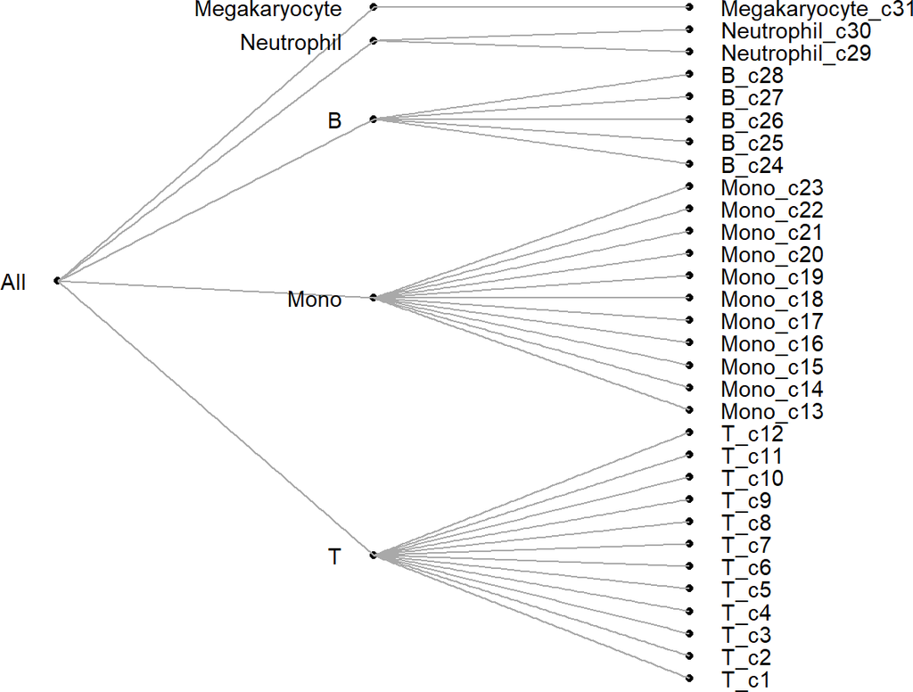

```r
s <- paste0('@All(',
            '@T(',paste0('T_c',c(1:12), collapse = ','),'),',
            '@Mono(',paste0('Mono_c',c(13:23), collapse = ','),'),',
            '@B(',paste0('B_c',c(24:28), collapse = ','),'),',
            '@Neutrophil(',paste0('Neutrophil_c',c(29:30), collapse = ','),'),',
            '@Megakaryocyte(',paste0('Megakaryocyte_c',c(31), collapse = ','),'))')

hierarchy_list <- extract_hrchy_string(s,'@') # tree is plotted in bottom-up fashion.
```

This is an example of how to construct hierarchical tree structure based on the string input. We identify five major immune cell types, including T cells, Monocytes, B cells, Neurtrophil and Megakaryocte. Within each large immune cell type, we can identify several cell subclusters.

# 5 Run Pseudotime

We provide a unified and easy-to-use function to run pseduotime analysis, which only requires the input of raw gene expression data, cell-level metadata, sample-level metadata, and hierarichial tree structure. The output will consist of list of pseudo bulk gene expression data, list of cell type proportion data, and sample pseudotime (automatic selected).

Some highlights of the key arguments in the function: users have the option to select features to construct pseudotime, which includes `expr` (gene expression), `prop` (cell proportion), and `expr_and_prop` (both gene expression and cell proportion). The pseudotime construction methods can be classified into two broad categories, i.e. semi-supervised approach `cca` and unsupervised approaches such as `tscan` and `mst`. Users also can specify the clustering methods from `mclust`, `kmeans` and `louvain`. The `eval_method` argument indicates the metrics used to automatically select the optimal pseudotime construction.

```r
ptime_result = runPseudotime(raw_count = raw_count,
                             cell_meta = cell_meta,
                             sample_meta = sample_meta,
                             leaves_info = leaves_info,
                             features = 'expr_and_prop',
                             batch = NULL,
                             pb_filter_pct = 0.9,
                             pb_HVG = T,
                             pb_qnorm = T,
                             pb_batch_correction = F,
                             pb_parallel = F,
                             ctp_clr = F,
                             ctp_adj_cov = NULL,
                             ctp_batch_correction = F,
                             sample_name = 'sample',
                             severity_name = 'severity',
                             severity_num_name = 'sev.level',
                             ptime_method = 'cca',
                             clsutermethod = 'louvain',
                             cluster_id = NULL,
                             reduce = F,
                             clusternum = 2,
                             startcluster = 1,
                             near_nbr_num = 3,
                             modelNames = 'VVV',
                             pc_scale = T,
                             eval_method = 'corr')
```

```
## [1] "insufficient sample size for node Megakaryocyte"
## [1] "insufficient sample size for node T_c9"
## [1] "insufficient sample size for node T_c10"
## [1] "insufficient sample size for node T_c11"
## [1] "insufficient sample size for node T_c12"
## [1] "insufficient sample size for node Mono_c17"
## [1] "insufficient sample size for node Mono_c18"
## [1] "insufficient sample size for node Mono_c19"
## [1] "insufficient sample size for node Mono_c20"
## [1] "insufficient sample size for node Mono_c21"
## [1] "insufficient sample size for node Mono_c22"
## [1] "insufficient sample size for node Mono_c23"
## [1] "insufficient sample size for node B_c25"
## [1] "insufficient sample size for node B_c27"
## [1] "insufficient sample size for node B_c28"
## [1] "insufficient sample size for node Neutrophil_c30"
## [1] "insufficient sample size for node Megakaryocyte_c31"
```

```r
print(str(ptime_result))
```

```
## List of 4
##  $ pb.ls            :List of 2
##   ..$ node:List of 20
##   .. ..$ All           : num [1:5432, 1:9] 0.015 0.015 6.061 0.416 1.383 ...
##   .. .. ..- attr(*, "dimnames")=List of 2
##   .. .. .. ..$ : chr [1:5432] "A2M" "A4GALT" "AAK1" "AASS" ...
##   .. .. .. ..$ : chr [1:9] "CoV-92.1-Su" "CoV-87.1-Su" "CoV-87.2-Su" "CoV-140.1-Su" ...
##   .. ..$ T             : num [1:5963, 1:9] 5.95 3.0452 0.0153 1.4882 4.3728 ...
##   .. .. ..- attr(*, "dimnames")=List of 2
##   .. .. .. ..$ : chr [1:5963] "A1BG" "A1BG-AS1" "A2M" "A2M-AS1" ...
##   .. .. .. ..$ : chr [1:9] "CoV-92.1-Su" "CoV-87.1-Su" "CoV-87.2-Su" "CoV-140.1-Su" ...
##   .. ..$ Mono          : num [1:5790, 1:9] 6.095 0.302 1.75 5.485 4.774 ...
##   .. .. ..- attr(*, "dimnames")=List of 2
##   .. .. .. ..$ : chr [1:5790] "A1BG" "A2M-AS1" "AACS" "AAK1" ...
##   .. .. .. ..$ : chr [1:9] "CoV-92.1-Su" "CoV-87.1-Su" "CoV-87.2-Su" "CoV-140.1-Su" ...
##   .. ..$ B             : num [1:5359, 1:9] 0 4.795 0.541 1.93 2.779 ...
##   .. .. ..- attr(*, "dimnames")=List of 2
##   .. .. .. ..$ : chr [1:5359] "A4GALT" "AAAS" "AACS" "AAED1" ...
##   .. .. .. ..$ : chr [1:9] "CoV-92.1-Su" "CoV-87.1-Su" "CoV-87.2-Su" "CoV-140.1-Su" ...
##   .. ..$ Neutrophil    : num [1:2668, 1:9] 0 6.06 6.06 0 0 ...
##   .. .. ..- attr(*, "dimnames")=List of 2
##   .. .. .. ..$ : chr [1:2668] "AAR2" "AARS" "ABCA2" "ABCA7" ...
##   .. .. .. ..$ : chr [1:9] "CoV-92.1-Su" "CoV-87.1-Su" "CoV-87.2-Su" "CoV-127.1-Su" ...
##   .. ..$ T_c1          : num [1:5858, 1:9] 5.55 2.24 3.93 6.37 5.97 ...
##   .. .. ..- attr(*, "dimnames")=List of 2
##   .. .. .. ..$ : chr [1:5858] "A1BG" "A1BG-AS1" "AAED1" "AAK1" ...
##   .. .. .. ..$ : chr [1:9] "CoV-92.1-Su" "CoV-87.1-Su" "CoV-87.2-Su" "CoV-140.1-Su" ...
##   .. ..$ T_c2          : num [1:5936, 1:9] 6.402 0.249 0.249 5.138 6.839 ...
##   .. .. ..- attr(*, "dimnames")=List of 2
##   .. .. .. ..$ : chr [1:5936] "A1BG" "A2M" "A2M-AS1" "AAED1" ...
##   .. .. .. ..$ : chr [1:9] "CoV-92.1-Su" "CoV-87.1-Su" "CoV-87.2-Su" "CoV-140.1-Su" ...
##   .. ..$ T_c3          : num [1:5548, 1:9] 1.8 1.8 5.04 1.8 1.8 ...
##   .. .. ..- attr(*, "dimnames")=List of 2
##   .. .. .. ..$ : chr [1:5548] "A1BG-AS1" "AAAS" "AAED1" "AAR2" ...
##   .. .. .. ..$ : chr [1:9] "CoV-92.1-Su" "CoV-87.1-Su" "CoV-87.2-Su" "CoV-140.1-Su" ...
##   .. ..$ T_c4          : num [1:6072, 1:9] 6.118 3.032 0.436 6.466 1.097 ...
##   .. .. ..- attr(*, "dimnames")=List of 2
##   .. .. .. ..$ : chr [1:6072] "A1BG" "A1BG-AS1" "A2M-AS1" "AAK1" ...
##   .. .. .. ..$ : chr [1:9] "CoV-92.1-Su" "CoV-87.1-Su" "CoV-87.2-Su" "CoV-140.1-Su" ...
##   .. ..$ T_c5          : num [1:5229, 1:9] 6.09 5.456 0.729 0.729 5.456 ...
```

[output cut: 155 more lines]

```
##   .. .. .. ..$   : chr [1:5] "PC1" "PC2" "PC3" "PC4" ...
##  $ sample_meta_ptime:List of 2
##   ..$ sample_info:'data.frame':  9 obs. of  9 variables:
##   .. ..$ sample    : chr [1:9] "CoV-170.1-Su" "CoV-163.2-Su" "CoV-151.2-Su" "CoV-203.1-Su" ...
##   .. ..$ study     : chr [1:9] "Su" "Su" "Su" "Su" ...
##   .. ..$ age       : num [1:9] 19 75 51 50 53 26 89 89 26
##   .. ..$ sex       : chr [1:9] "F" "F" "F" "F" ...
##   .. ..$ severity  : chr [1:9] "Mi" "Mi" "Mi" "Mi" ...
##   .. ..$ batch     : chr [1:9] "Su" "Su" "Su" "Su" ...
##   .. ..$ sev.level : num [1:9] 2 2 2 2 2 3 3 3 3
##   .. ..$ id        : int [1:9] 123 112 93 183 75 7 55 14 6
##   .. ..$ pseudotime: num [1:9] 1 2 3 4 5 6 7 8 9
##   ..$ slope      : Named num -0.0993
##   .. ..- attr(*, "names")= chr "PC2"
## NULL
```

# 6 Run DEG

We provide the fucntion `runPseudoDEG` to identify the differentially expressed genes over pseduotime based on the prespecified tree structure. The DEG results are provided at each internal tree node and they are readily available for downstream TreeCorTreat analysis.

```r
sample_meta_ptime = ptime_result$sample_meta_ptime$sample_info
pb.ls = ptime_result$pb.ls
pb.ls.node = pb.ls$node


deg_result = runPseudoDEG(sample_meta = sample_meta_ptime, pb.ls = pb.ls,
                          leaves_info = leaves_info, phenotype_name = 'severity',
                          pseudotime_name = 'pseudotime')
deg_table = deg_result$tab
deg_summary = deg_result$num_DEG
print(deg_summary)
```

```
##                label     x y id  leaf severity.num_DEGs
## 1                All 17.75 2  1 FALSE                44
## 32                 T  5.50 1  2 FALSE                15
## 44              Mono 17.00 1  3 FALSE                64
## 55                 B 25.00 1  4 FALSE               256
## 60        Neutrophil 28.50 1  5 FALSE               469
## 62     Megakaryocyte 30.00 1  6 FALSE                 0
## 63              T_c1  0.00 0  7  TRUE                26
## 64              T_c2  1.00 0  8  TRUE                83
## 65              T_c3  2.00 0  9  TRUE               165
## 66              T_c4  3.00 0 10  TRUE                23
## 67              T_c5  4.00 0 11  TRUE               842
## 68              T_c6  5.00 0 12  TRUE               765
## 69              T_c7  6.00 0 13  TRUE               670
## 70              T_c8  7.00 0 14  TRUE               692
```

[output cut: 23 more lines]

# 7 Sample-Level Low-Dimensional Representation

In this section, we demonstrate the low-dimensional representation of each sample, and use canonical correlation based methods to identify the optimal axis that has the largest correlation with severity level. The optimal axis reveals the disease progression from mild to moderate status.

```
## [1] 1
```

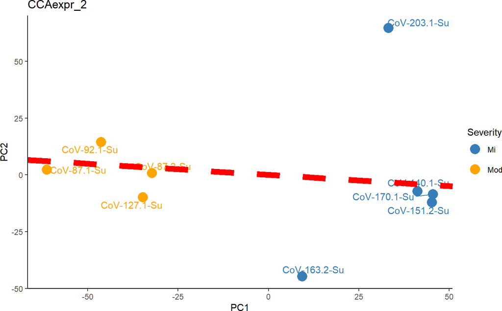

```
## [1] 2
```

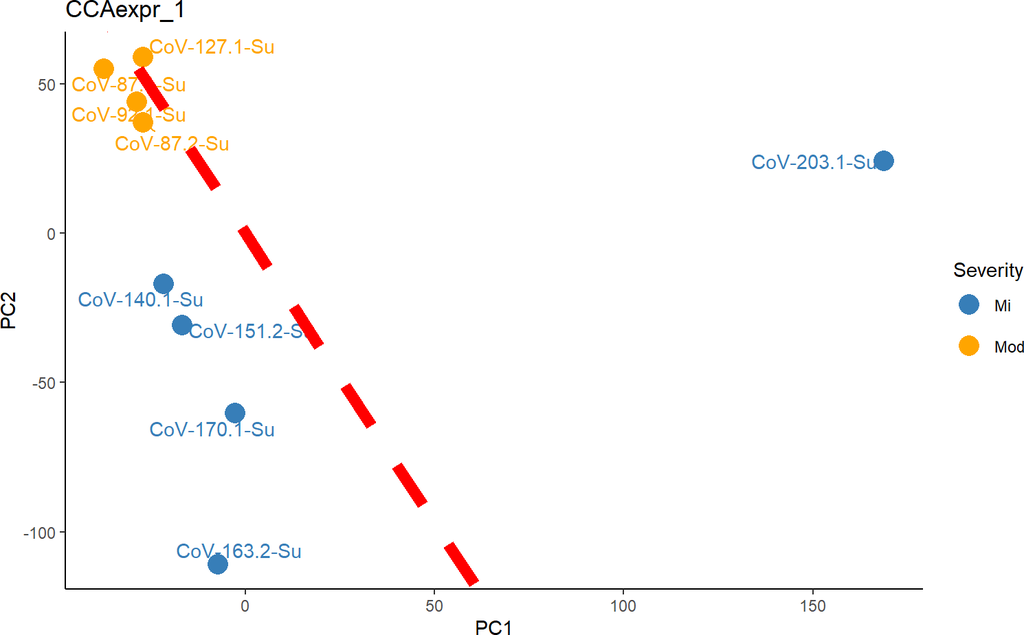

```
## [1] 3
```

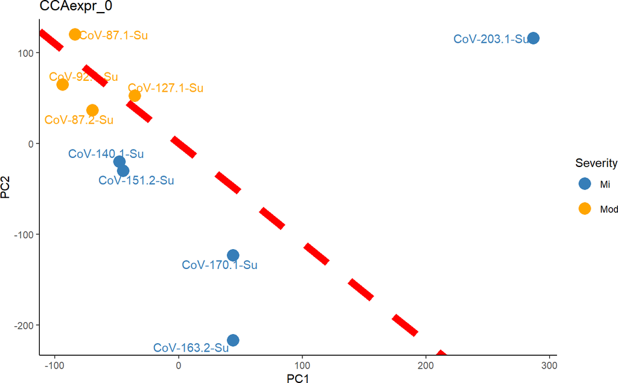

```
## [1] 4
```

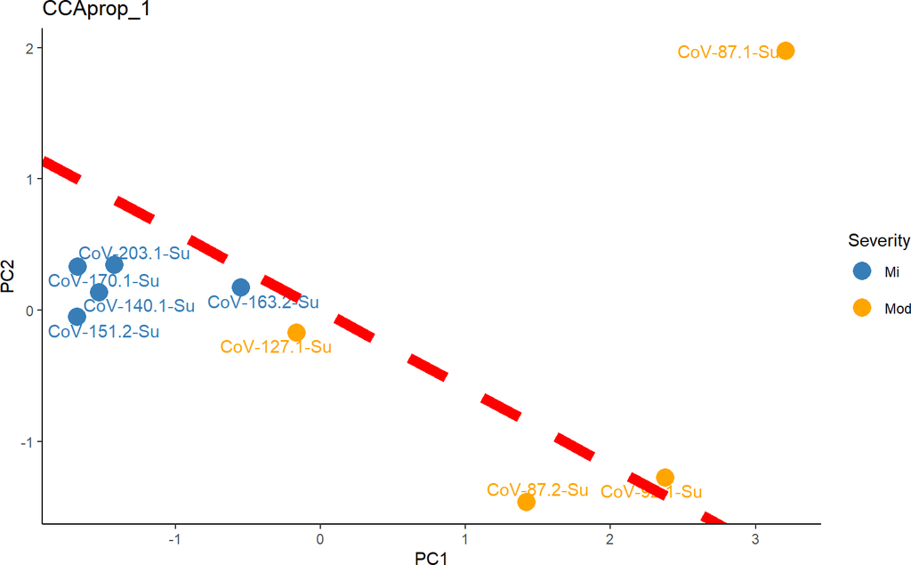

```
## [1] 5
```

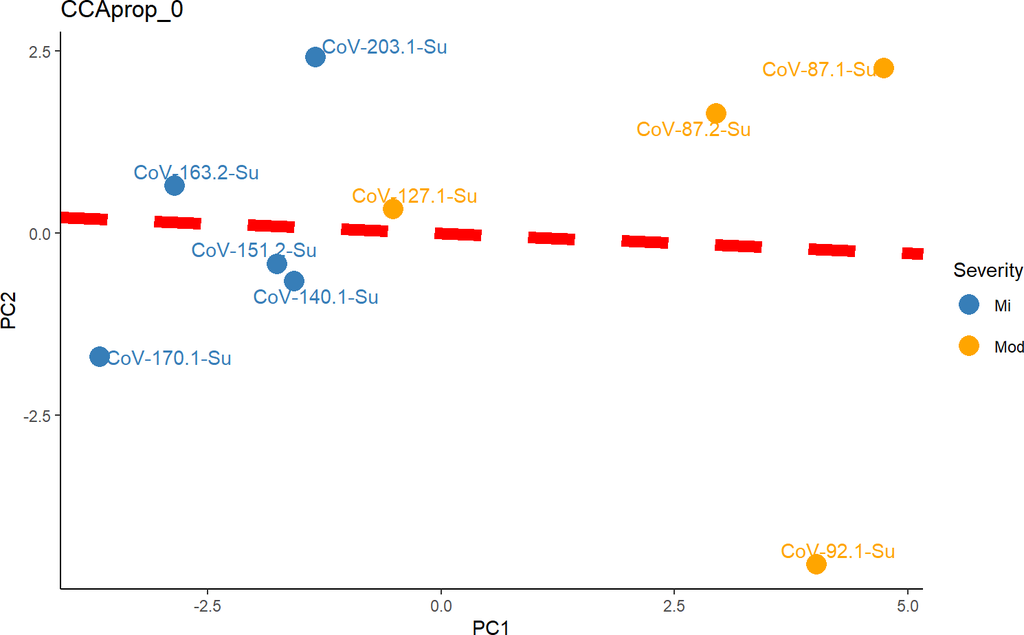

```r
severity.color = readRDS("./data/demo/severity.rds")
study.color = readRDS("./data/demo/study.rds")

create_pseudotime_plot = function(sample_info, rd, title, slope = NULL){

  sample_info = rd %>%
    as.data.frame() %>%
    mutate(sample = rownames(.)) %>%
    inner_join(sample_info, by = 'sample') %>%
    filter(study == 'Su')

  p1 = ggplot(aes(x = PC1, y = PC2, color = severity, label = sample), data= sample_info)+
    geom_point(size = 5)+
    scale_colour_manual(values = severity.color)+
    geom_text_repel()+
    geom_abline(slope = slope, intercept = 0, linetype = 'dashed', col = 'red', size = 3)+
    guides(colour = guide_legend(nrow=2,byrow=TRUE)) +
    labs(color = "Severity") +
    ggtitle(title)+
    theme_classic()

  return(p1)
}

ptime.ls = ptime_result$ptime.ls
for (i in 1:length(ptime.ls)){
  print(i)
  p1 = create_pseudotime_plot(sample_info = ptime.ls[[i]]$ptime$sample_info, rd = ptime.ls[[i]]$rd,
                              title = paste0("CCA", names(ptime.ls)[i]),
                              slope = ptime.ls[[i]]$ptime$slope)
  print(p1)

}
```

# 8 Cell Proportion Dynamic Trajectory

Now we are going to show how the cell proportion changes along the pseudotime by fitting a smooth curve.

```r
get_cell_prop_traj = function(cell_type_prop,
                              sample_metadata = NULL,
                              sample_name = 'sample', pseudotime_name = 'pseudotime'){

  rn = rownames(cell_type_prop)
  celltype_list = gsub('(.*)_(.*)','\\1', rn)
  cluster_list = gsub('(.*)_(.*)','\\2', rn)
  celltype_label = paste0(cluster_list, '\n', celltype_list)
  patient_order = sample_metadata[, sample_name]

  cp = cell_type_prop[, match(patient_order,colnames(cell_type_prop)),drop = F]

  cp_df = cp %>%
    as.data.frame() %>%
    mutate(celltype = celltype_label) %>%
    gather(!!sample_name, value, -celltype) %>%
    inner_join(sample_metadata %>% dplyr::select({{sample_name}}, {{pseudotime_name}}), by = sample_name)

  str(cp_df)

  p = cp_df %>%
    mutate(celltype = factor(celltype, levels = celltype_label)) %>%
    ggplot(aes(x = get(pseudotime_name), y = value))+
    geom_point()+ geom_smooth()+
    facet_wrap(vars(celltype),scales = "free_y")+
    ylab("Cell Type Proportion")+
    theme_classic()

  return(p)

}

ctp = get_ctp(clu = cell_meta$celltype, pt = cell_meta$sample)
p1 = get_cell_prop_traj(cell_type_prop = ctp,
                        sample_metadata = sample_meta_ptime)
```

```
## 'data.frame':    225 obs. of  4 variables:
##  $ celltype  : chr  "c24\nB" "c25\nB" "c26\nB" "c27\nB" ...
##  $ sample    : chr  "CoV-170.1-Su" "CoV-170.1-Su" "CoV-170.1-Su" "CoV-170.1-Su" ...
##  $ value     : num  0.04 0.000851 0.001702 0.000851 0 ...
##  $ pseudotime: num  1 1 1 1 1 1 1 1 1 1 ...
```

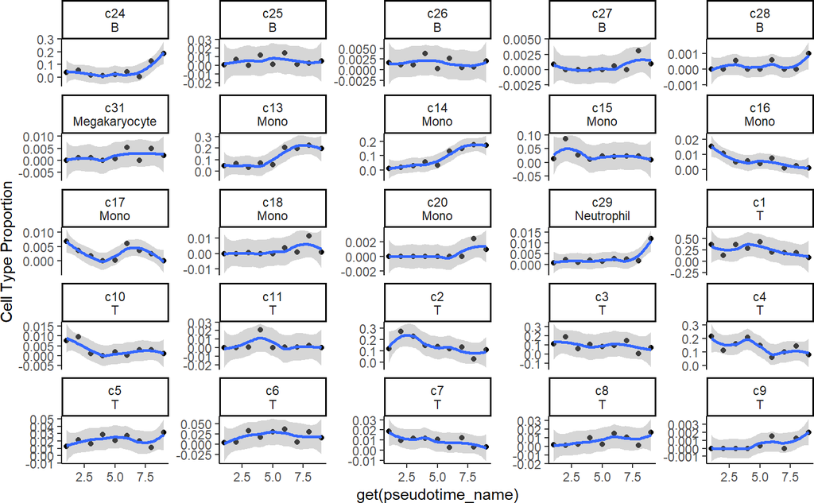

```r
p1
```

# 9 Gene Expression Dynamic Trajectory

Now we are going to show how the expression levels of specific genes in specific clusters change over the pseudotime.

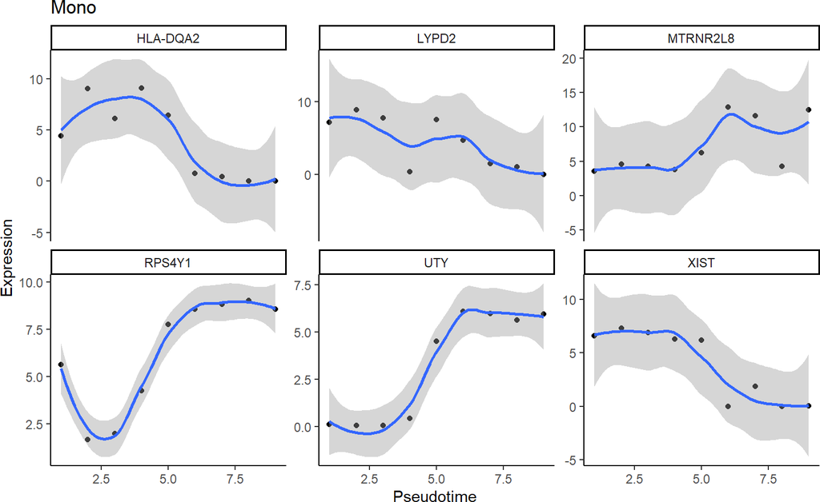

```r
get_gene_expr_traj = function(x, gene_list, cluster, sample_metadata,
                              pseudotime_name = 'pseudotime',
                              sample_name = 'sample'){
  ptime = sample_metadata[,pseudotime_name]
  sample_metadata = sample_metadata[order(ptime),]
  match_id = match(sample_metadata[, sample_name], colnames(x))
  x = x[gene_list, match_id , drop = F]
  colnames(x) = 1:ncol(x)


  df = x %>%
    as.data.frame() %>%
    mutate(gene=rownames(.)) %>%
    pivot_longer(!gene, names_to = 'Pseudotime', values_to = 'Expression') %>%
    mutate(Pseudotime = as.numeric(Pseudotime))

  p = df%>%
    ggplot(aes(x = Pseudotime, y = Expression))+
    geom_point()+ geom_smooth()+
    facet_wrap(vars(gene), scales = "free_y") +
    ggtitle(cluster)+
    theme_classic()
  return(p)
}
p = get_gene_expr_traj(x = pb.ls.node[['Mono']],
                       gene_list = c("HLA-DQA2","XIST", "LYPD2", "MTRNR2L8", "UTY", "RPS4Y1"), #head(deg_table[['Mono']]$gene),
                       cluster = 'Mono',
                       sample_metadata = sample_meta_ptime)
p
```